# Laboratorio 1.2: Exploración y Visualización de Datos

Andrés Calderón y Franco González

Agosto 2023

# Declaración de compromiso ético

Nosotros Andrés Calderón y Franco González, declaramos que realizamos de manera grupal los pasos de la presente actividad. También declaramos no incurrir en copia, ni compartir nuestras respuestas con otras personas ni con otros grupos. Por lo que, ratificamos que las respuestas son de nuestra propia confección y reflejan nuestro propio conocimiento.

# Instrucciones

1. Trabajen en equipos de dos personas. Salvo excepciones, no se corregirá entregas con menos de dos integrantes.
2. Modifique este archivo `.Rmd` agregando sus respuestas donde corresponda.
3. Para cada pregunta, cuando corresponda, **incluya el código fuente que utilizó para llegar a su respuesta**.
4. El formato de entrega para esta actividad es un archivo html. **Genere un archivo HTML usando RStudio** y súbalo a U-Cursos.

Basta con que uno de los integrantes haga la entrega. Si ambos hacen una entrega en U-Cursos, se revisará cualquiera de éstas.

## Práctica

### Accidentes de tránsito

Para esta sección utilizaremos un dataset real de número de accidentes de tránsito por localidad, el cual puede ser encontrado en el siguiente link: http://datos.gob.cl/dataset/9348. Para cargar el dataset ejecute el siguiente código:

```r
tipos <- read.table("https://users.dcc.uchile.cl/~hsarmien/mineria/datasets/accidentes_2010_2011.txt")
head(tipos)
```

```
##    Muestra                  Descripcion Anio TipoAccidente Cantidad
## 1 Nacional                     Nacional 2010     Atropello     8247
## 2 Nacional                     Nacional 2011     Atropello     8339
## 3 Regional XV Región Arica y Parinacota 2010     Atropello      115
## 4 Regional XV Región Arica y Parinacota 2011     Atropello      159
## 5  Comunal                        ARICA 2010     Atropello      115
## 6  Comunal                        ARICA 2011     Atropello      158
```

Explore el set de datos para responder las siguientes preguntas:

1. ¿Cuáles son las dimensiones del dataset (filas, columnas)? (Recuerde adjuntar código).

```r
dim(tipos)
```

```
## [1] 4296    5
```

2. ¿Qué describe cada línea del dataset? (ejemplifique tomando el dato de la fila 235, extienda la descripción)

Para este caso particular tendríamos que en la comuna de Palmilla durante el año 2010 hubieron 4 atropellos, extendiendo esto a una descripción general sería el equivalente a que nos mencionan el tipo de accidente, las veces que sucedió, el lugar y el año en el que ocurrió.

```r
tipos[235,]
```

```
##     Muestra Descripcion Anio TipoAccidente Cantidad
## 235 Comunal    PALMILLA 2010     Atropello        4
```

3. ¿Cuántos años diferentes abarca la información del dataset? Entregue una tabla que contenga los valores únicos que hay en la columna Anio.

```r
unique(tipos$Anio)
```

```
## [1] 2010 2011
```

4. Filtre los datos para incluir sólo los accidentes ocurridos el año 2011 a nivel Regional. Luego, genere un gráfico de barras que muestre la cantidad de accidentes en cada Región. Comente sus principales observaciones y si considera que es razonable usar el conteo de frecuencias para determinar las regiones que tuvieron más accidentes.

Se observa una región con muchos accidentes de un cierto tipo por lo que en este ámbito sería razonable usar el conteo de frecuencias, pero es díficil de decir cual en específico por el tipo de gráfico además de que no es posible identificar el detalle de la información.

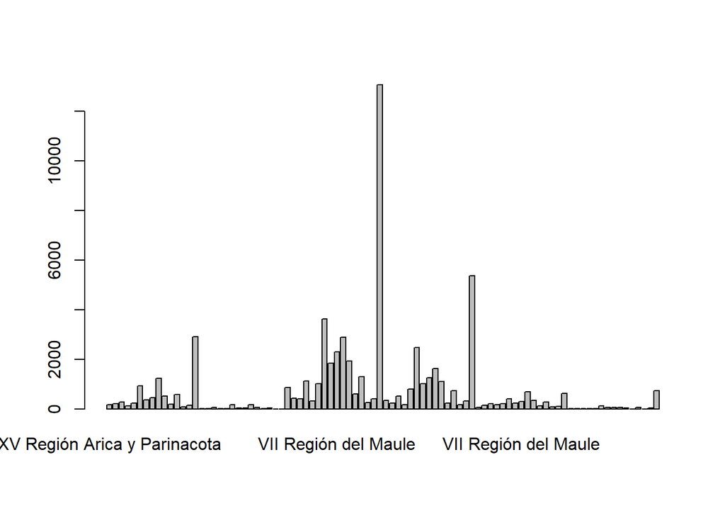

```r
#tipos_2011 <- tipos[tipos$Muestra == 'Regional' & tipos$Anio == 2011, ]
tipos_2011 <- subset(tipos, Muestra == 'Regional' & Anio == 2011)
barplot(tipos_2011$Cantidad, names.arg = tipos_2011$Descripcion)
```

5. Filtre los datos para incluir sólo los accidentes ocurridos el año 2010 a nivel regional. Genere un boxplot donde se indique la cantidad de accidentes categorizado por tipo de accidente. ¿Cuáles son sus principales observaciones?

Sin poner un límite vertical se podía observar un outlier en colisión que está en alrededor de 12000 además de que es evidente que colisión es el que tiene valores más altos y en base a este gráfico existen regiones en que los valores son muy altos pero para la mayoría de regiones estas cantidades están cerca de la media.

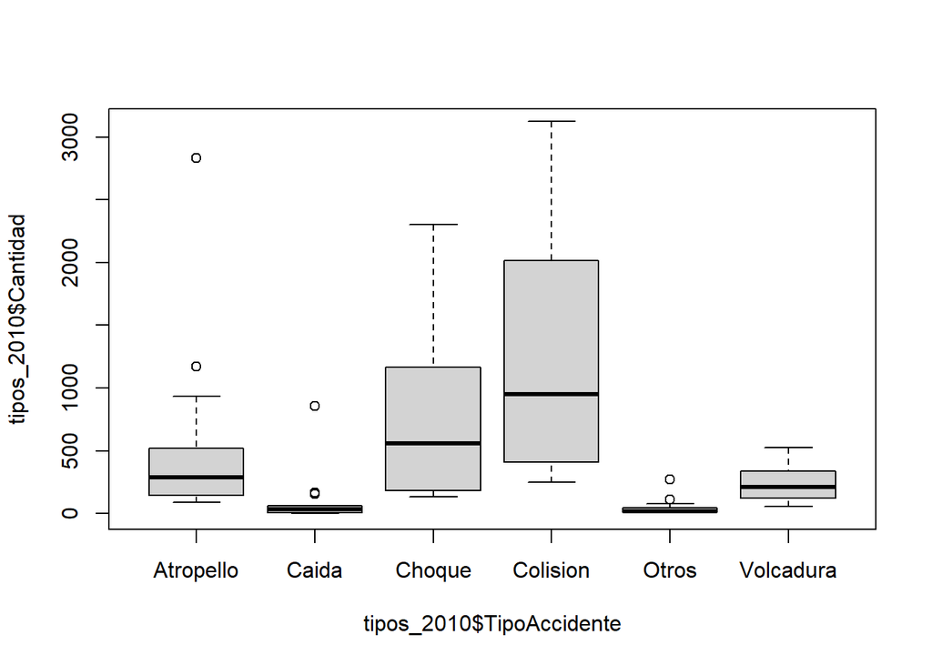

```r
tipos_2010 <- tipos[tipos$Muestra == "Regional" & tipos$Anio == 2010, ]
boxplot(tipos_2010$Cantidad ~ tipos_2010$TipoAccidente, ylim=c(0,3100))
```

6. ¿Qué otra forma de explorar los datos podría agregar para el dataset de Accidentes de tránsito y qué información adicional aporta? Adjunte el código necesario.

En este caso podemos visualizar con mayor precisión la ocurrencia de cada tipo de accidente por separado.

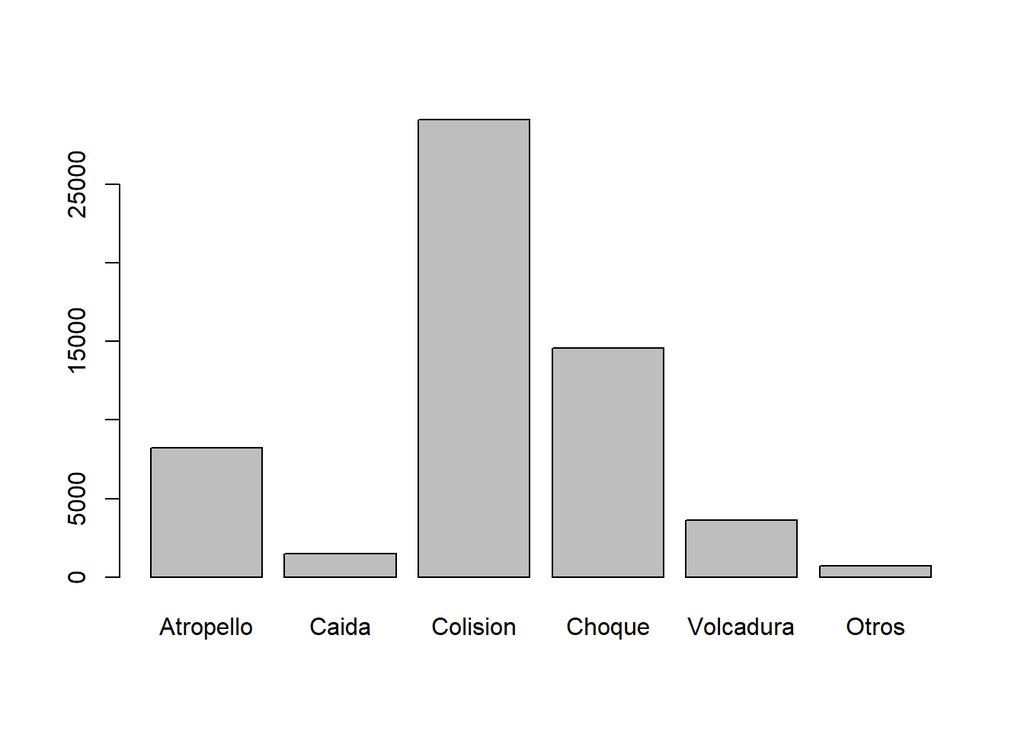

```r
tipos_comuna <- subset(tipos, Muestra == 'Nacional' & Anio == 2010)
barplot(tipos_comuna$Cantidad, names.arg = tipos_comuna$TipoAccidente)
```

### Diabetes

Considere el set de datos de pacientes para la predicción de diabetes con las siguientes columnas:

- gender: género del paciente
- age: edad del paciente
- hypertension: indica si el paciente tiene o no hipertensión
- heart_disease: indica si el paciente tiene o no enfermedad cardiaca
- smoking_history: indica si el paciente es o fue fumador
- bmi: indice de masa corporal del paciente
- HbA1c_level: Hemoglobina HbA1c del paciente
- blood_glucose_level: Nivel de glucosa en sangre del paciente
- diabetes: si el paciente tiene o no diabetes

```r
# Load diabetes dataset

diabetes <- read.csv("https://raw.githubusercontent.com/mzambrano1/Datasets-CC5205-otono-2023/master/lab1.2%202023-2/diabetes_prediction_dataset.csv")
head(diabetes)
```

```
##   gender age hypertension heart_disease smoking_history   bmi HbA1c_level
## 1 Female  80            0             1           never 25.19         6.6
## 2 Female  54            0             0         No Info 27.32         6.6
## 3   Male  28            0             0           never 27.32         5.7
## 4 Female  36            0             0         current 23.45         5.0
## 5   Male  76            1             1         current 20.14         4.8
## 6 Female  20            0             0           never 27.32         6.6
##   blood_glucose_level diabetes
## 1                 140        0
## 2                  80        0
## 3                 158        0
## 4                 155        0
## 5                 155        0
## 6                  85        0
```

7. Para explorar el dataset, realice un análisis de frecuencias de los atributos categóricos (categorías binarias y multiclase).

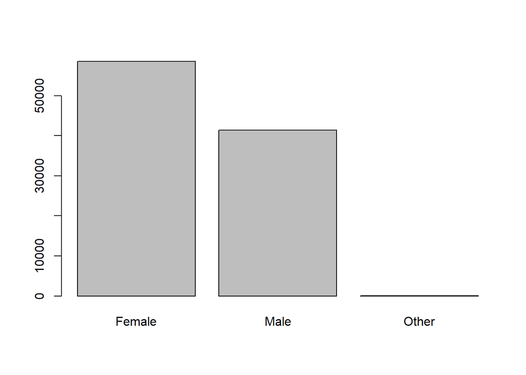

```r
barplot(table(diabetes$gender))
```

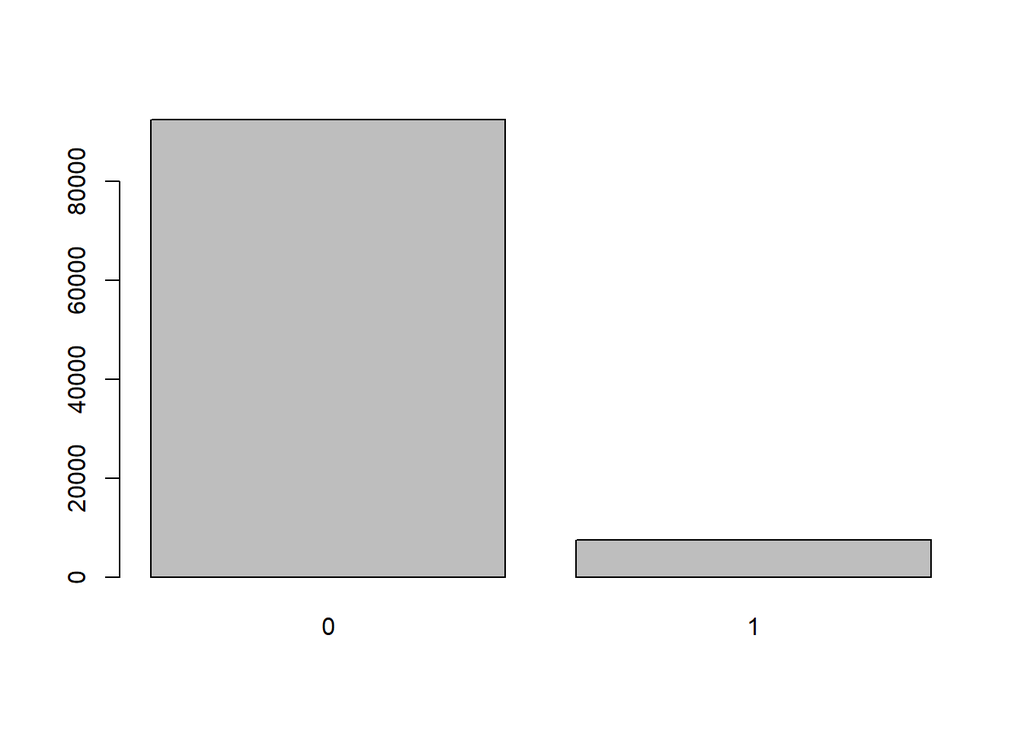

```r
barplot(table(diabetes$hypertension))
```

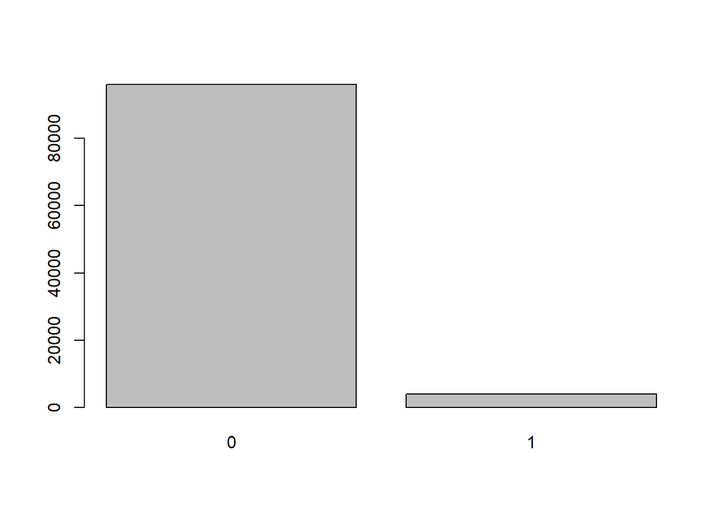

```r
barplot(table(diabetes$heart_disease))
```

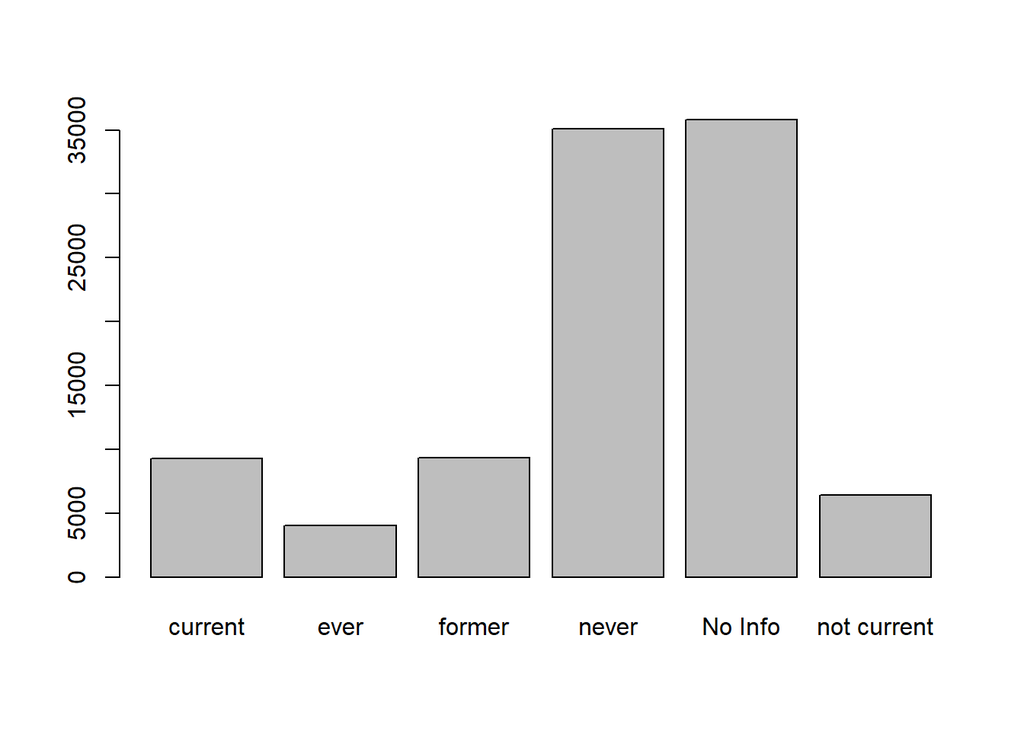

```r
barplot(table(diabetes$smoking_history))
```

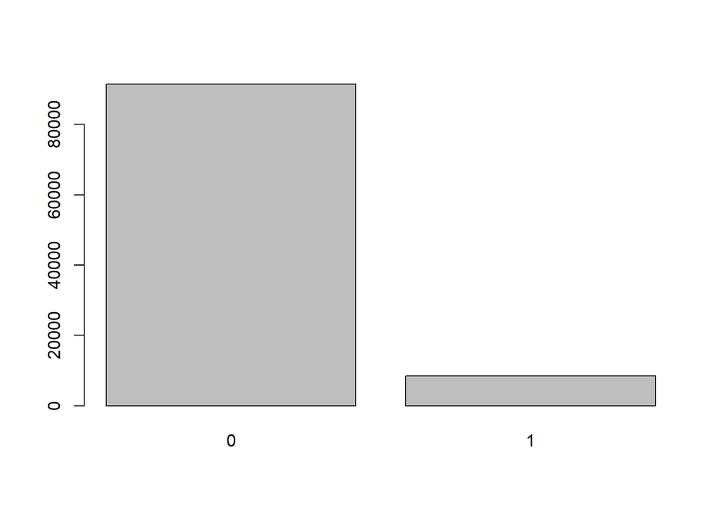

```r
barplot(table(diabetes$diabetes))
```

8. Muestre estadísticas de resumen para las variables numéricas y comente sus observaciones.

La mayoría de datos binarios son 0. Algo destacable es que en el BMI y la glucosa la mediana se aleja mucho del máximo pero son pocos estos valores, ocurriendo algo parecido con diabetes de modo que se puede deducir una correlación no menor, esto podemos generalizarlo con todos los datos binarios pues tienen un comportamiento parecido de poseer muchos ceros pero pocos unos, de modo que estos 1 se relacionan mucho con las diabetes. Para el resto de atributos tienen una distribución bastante estándar.

```r
summary(diabetes$age)
```

```
##    Min. 1st Qu.  Median    Mean 3rd Qu.    Max.
##    0.08   24.00   43.00   41.89   60.00   80.00
```

```r
sd(diabetes$age)
```

```
## [1] 22.51684
```

```r
summary(diabetes$hypertension)
```

```
##    Min. 1st Qu.  Median    Mean 3rd Qu.    Max.
## 0.00000 0.00000 0.00000 0.07485 0.00000 1.00000
```

```r
sd(diabetes$hypertension)
```

```
## [1] 0.2631505
```

```r
summary(diabetes$heart_disease)
```

```
##    Min. 1st Qu.  Median    Mean 3rd Qu.    Max.
## 0.00000 0.00000 0.00000 0.03942 0.00000 1.00000
```

```r
sd(diabetes$heart_disease)
```

```
## [1] 0.194593
```

```r
summary(diabetes$bmi)
```

```
##    Min. 1st Qu.  Median    Mean 3rd Qu.    Max.
##   10.01   23.63   27.32   27.32   29.58   95.69
```

```r
sd(diabetes$bmi)
```

```
## [1] 6.636783
```

```r
summary(diabetes$HbA1c_level)
```

```
##    Min. 1st Qu.  Median    Mean 3rd Qu.    Max.
##   3.500   4.800   5.800   5.528   6.200   9.000
```

```r
sd(diabetes$HbA1c_level)
```

```
## [1] 1.070672
```

```r
summary(diabetes$blood_glucose_level)
```

```
##    Min. 1st Qu.  Median    Mean 3rd Qu.    Max.
##    80.0   100.0   140.0   138.1   159.0   300.0
```

```r
sd(diabetes$blood_glucose_level)
```

```
## [1] 40.70814
```

```r
summary(diabetes$diabetes)
```

```
##    Min. 1st Qu.  Median    Mean 3rd Qu.    Max.
##   0.000   0.000   0.000   0.085   0.000   1.000
```

```r
sd(diabetes$diabetes)
```

```
## [1] 0.2788831
```

9. Considerando solo los atributos numéricos, elija una de las técnicas de selección de atributos vistas en clases y apliquela a los datos para obtener los dos atributos que más información entregan, teniendo en cuenta que este datset podría usarse para predecir si alguien tiene o no diabetes. ¿Qué atributos se seleccionaron? ¿Le hace sentido que sean estos los más importantes? Visualice como se relacionan estos dos atributos, identificando si cada dato corresponde a alguien con diabetes o no ¿que observaciones puede hacer?

Terminamos seleccionando los atributos “blood_glucose_level” y “HbA1c_level”, en este caso nos estos 2 valores miden los niveles de glucosa en el individuo y sabemos que la diabetes esta fuertemente asociado con los altos niveles de estos en sangre de modo que nos hace sentido esta correlación. Pese a esto, entre sí estos 2 atributos no tienen una correlación tan alta como cada una por separado con la diabetes.

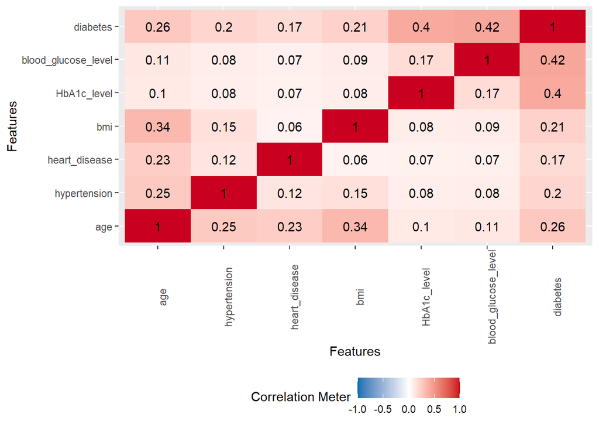

```r
library("DataExplorer")
plot_correlation(diabetes[,c("age", "hypertension", "heart_disease", "bmi", "HbA1c_level", "blood_glucose_level", "diabetes")])
```